# 来一发megui吧！

莱姆籽(来一发就走字幕组)

2017-05-06

# 1 如何用Megui压制视频

## 1.1 准备工作

安装如下软件

- 安装[MeGUI](https://sourceforge.net/projects/megui/)
- 安装[K-Lite_Codec](http://www.codecguide.com/download_kl.htm)
- 在开始菜单程序里的`MeGUI Chinese language`目录里安装K-Lite_Codec_Pack解码器[^1]
- 安装完美解码-PureCodec

> **安装设置解码器 (解决加载字幕问题)**

```
在创建AVS脚本时，很多不明的问题常常出现。就是因为解码这一环节，比如系统装过很多自带解码的播放器，如，暴风影音、QQ影音、KMplayer等内置有解码块的，这就造成再次安装解码器时出现不稳定的情况，应该卸载这类播放器，在进行安装，必要时重做系统只安装推荐的一个解码器。大量的试用证明：K-Lite_Codec_Pack强烈建议用在专用压制机器上，在win7系统上更稳定，若是只做来学习用的机器，强烈建议安装【完美解码】因为它比较容易设置更改各类型视频格式的解码器，在压制时可随设置随观察AVS的预览变化。
为了解决TS、TP 等MPEG-2视频在AVS下不能正确加载显示字幕包括特效字幕压制问题，特别说明一下安装解码器的一些设置。
首先以安装K-Lite_Codec_Pack为例：正常化默认安装到第三步，如下图，应该选择MPEG-2,DVD这一项使用ffdshow(libavcodec)或者是ffdshow(libmpeg2)任何一个作业解码。
```

[figure not shown]

```
简单的一步就可以解决一个大问题，如果事先安装了没有知道选择这一项，也可以在解码器的安装菜单栏文件夹里找到设置更改项修改（这里不介绍如何修改了，自动摸索吧），windows xp比较容易设置，windows 7就有点复杂，建议没能显示字幕的朋友卸载解码器重新安装选择一下更省力，或者用完美解码一类的解码器安装后比较容易设置。
W1in7专用解码Win7codecs安装到最后可以设置如下：
```

[figure not shown]

```
其它的解码器也是一样的，为什么要这样设置才可以加载字幕呢？这应该是解码器对视频硬解码和软解码的问题导致内部外挂字幕滤镜VSFilter.dll失效，通过试测硬解时TS、TP视频无法加载字幕包括特效字幕，调设为软解时就可以正常显示。在硬解与软解下看avs播放的占用率, 硬解比软解利用率更高,估计是倒来倒去的关系，cpu-显卡-cpu，而软解只是在cpu内部，这些设置不关系到视频压制的编码质量。
```

## 1.2 创建AVS脚本

可在上面编辑代码，对视频进行处理

`选择 脚本创建器`

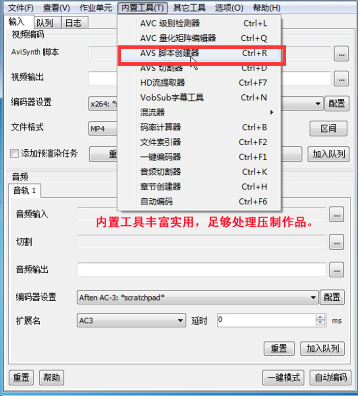

[figure not shown]

选择打开视频的方式（一般选DirectShow…，若预览视频出现黑屏现象，可重新创建avs选择File Indexer方式）

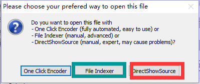

调整视频尺寸

[figure not shown]

若视频本身比预定的尺寸小，在这里是调不了的，需要点到script部分，手动修改代码

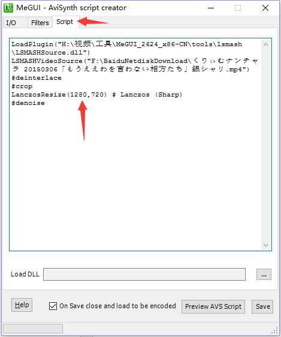

添加字幕

[figure not shown]

点击保存即可

[figure not shown]

## 1.3 配置输出参数

先在这里选择X264

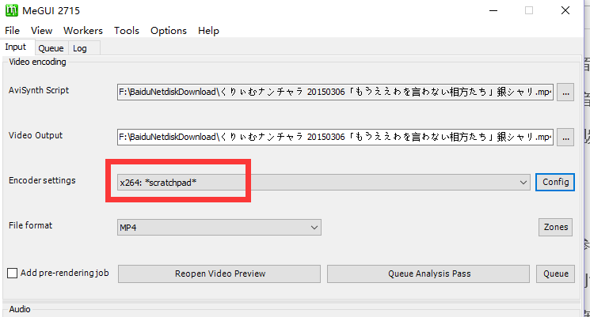

点击config（配置）弹出窗口

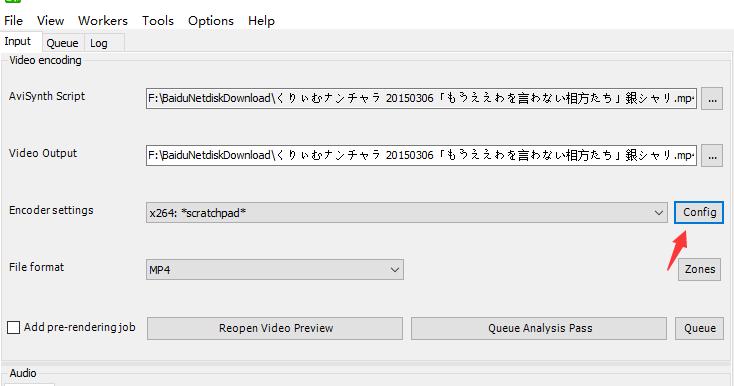

[figure not shown]

所有参数可参考本图中的进行设置一般不会出错

码率部分（bitrate）每次输出时修改来控制视频质量

以下部分，除了“主要“可以在每次压制时进行调整，其他都一次性设置之后都不用修改

[figure not shown]

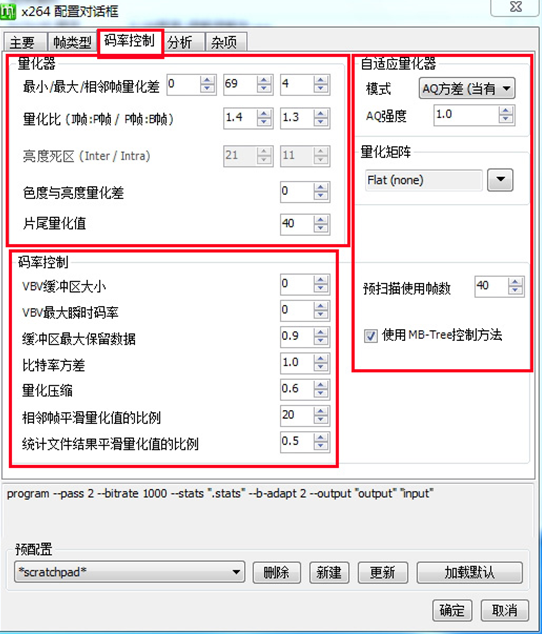

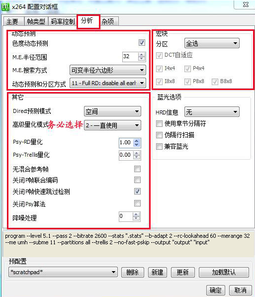

## 1.4 调整声音延迟

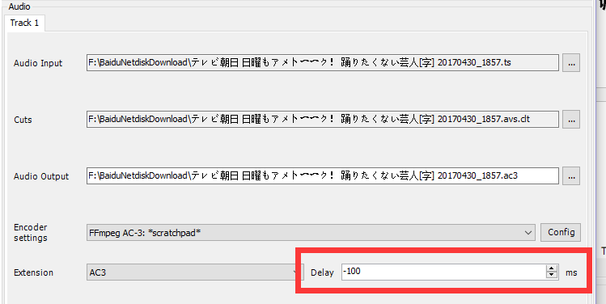

[output not shown]

设置好后点ok（确定）即可

## 1.5 压制

点击 `AutoEncode`

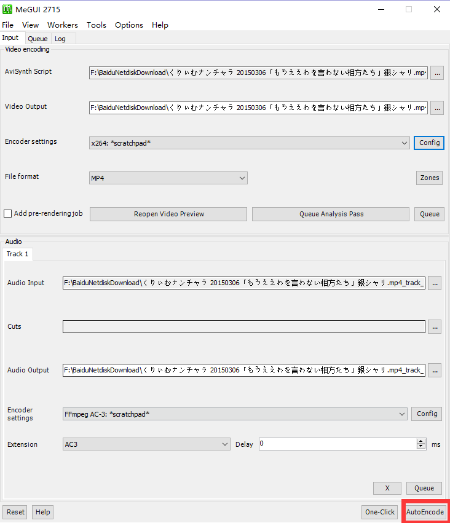

勾选无目标尺寸—队列即可开始压制

[figure not shown]

# 2 如何用Megui剪辑视频

## 2.1 待剪切影片准备(略)

## 2.2 记录cut时间点（帧）

### 2.2.1 使用Aeguisub记录帧数

[figure not shown]

### 2.2.2 记下来

[output not shown]

### 2.2.3 **重要** 调整帧数延迟

[output not shown]

## 2.3 Megui cut和压制

### 2.3.1 创建AVS

[figure not shown]

选择 `Tools-AVS script creator`

[figure not shown]

拖进来

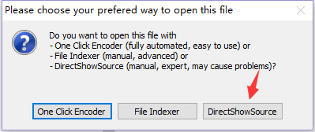

选择direct show source

[figure not shown]

修改分辨率之后保存

### 2.3.2 创建剪切文件

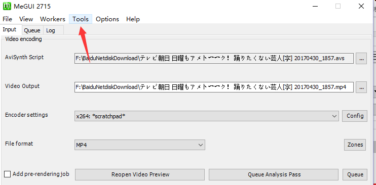

选择tools—AVS cutter

[figure not shown]

选择刚刚创建的AVS

[figure not shown]

数据输入进去，分别添加

[figure not shown]

全部添加完，选择do all and close

[figure not shown]

把CLT TS文件分别拖进去